# GraphMomemt

## グラフのモーメント

### ノードペア距離とノード上関数による、グラフモーメント

グラフ$G$のモーメントと言うものが定義されている。 https://arxiv.org/pdf/1208.5615.pdf にいくつかのそれが定義されている。

簡単に言うと、グラフの全ノードペアの距離$d(u,v);u,v \in V$と、ノードに付与したスカラー値 $\rho(u);u \in V$とから計算される、非負実数である。

$$M_G^\rho = f(d(u,v),\rho(u)); u,v \in V$$

### ノードの次数も考慮するグラフモーメントと、その派生インデックス

ノードの次数を$\rho$として用いるものや、ノードの次数からノードペア距離とは無関係に算出される値を別途、加えるインデックスなども、グラフのモーメントに関係する指数として用いることもある。

特に、化合物の構造の指数として考案されたもののようである。

以下では、$\rho=1$に統一して、モーメントを扱い($M_G^\rho$)、グラフのposet化との関連について検討する。

## グラフ、DAG(Directed Acyclic Graph)、Poset

この文書での興味は、以下の点にある。

- 単純無向グラフGが、ユークリッド空間に埋め込まれている
- Gの全情報は、頂点数$|V|$、エッジの引かれ方$E$、エッジ長情報で尽くされているものとする（閉曲面を表すグラフの場合などでは、局所の凹凸方向情報も必要となるが、今回は、それは考えないことにする）
- このとき、自由度は、$K=\frac{|V|(|V|-1)}{2} + |E|$であろう
- Gの隣接行列とエッジ長情報ベクトルが全て揃えば、グラフの異同を確認できるが、それでは面白く無いと考える
- グラフの異同度を定量することを目的として、より少ない数のスカラー値のセットにて異同度を表現したい
- 相互に（線形）非依存なK個の値の取り出し方のうち、目的に合致したものが取り出せることが望ましい
- Gの１つの頂点をルートノード$r$として定めると、全ての頂点とルートノード間にグラフ距離が定まる。この対ルートノードグラフ距離の値の比較を持って、ポセット＄(G,r,)$を構成することとする
- この$(G,r,\le)$にはモーメント$M_{(G,r,_le)}^{\rho=1}$が定まる
- グラフGとポセット$(G,r,\le)$との違いは、ポセットのエッジがGのエッジの部分集合になっていることと、エッジに向きがあることの２点である。言い換えると、ポセットのモーメントは、Gのモーメントの一部の説明になっている
- もしもあるポセット$(G,r_i,\le)$と別のポセット$(G,r_j,\le)$とがあって、両者を構成するエッジ$(E_{r_i},E_{r_j})$が排他的であれば、二つのポセットが説明するGのモーメントは排他的〜独立？？と言うような関係になるのでは無いだろうか
- もしも、ある限られたポセットにより、Gのモーメントが分解して説明されたとすると、そのポセットは「固有ポセット」とでも言うようなものになる
- なお、Gの距離行列が与えられているとき、MDSを行うことにより、ある意味、無理矢理にユークリッド空間に埋め込むこともできて、そのときの、各ノードのMDS座標は、ポセットとは別の意味での頂点間距離となっているから、それの意味についても検討することとしたい
- なお、実際には$(G,r,\le)$は実数直線上の点列ともみなせるので、普通の意味での、k-次モーメントも定まる。これはグラフ情報の自由度を増やす手段としても興味深い

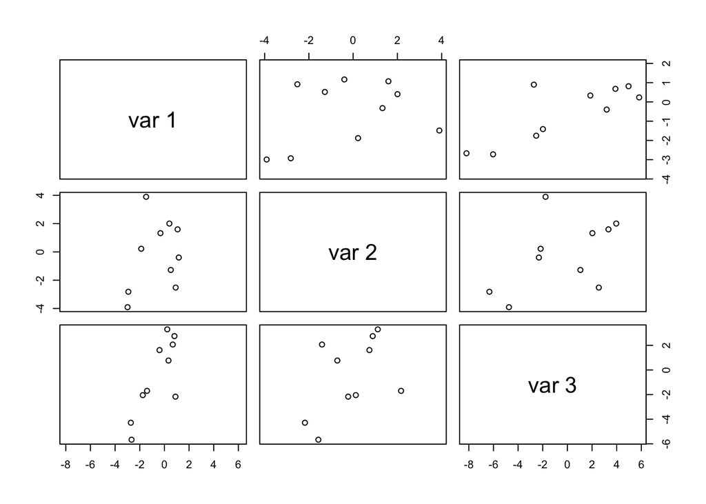

```r
d <- 3
n <- 10
X <- matrix(rnorm(d*n),ncol=d)
library(GPArotation)
R <- Random.Start(d)
X <- t(t(X)*c(1,2,4))
X. <- X %*% R

library(rgl)
plot3d(X.)
pairs(X.,asp=TRUE)
```

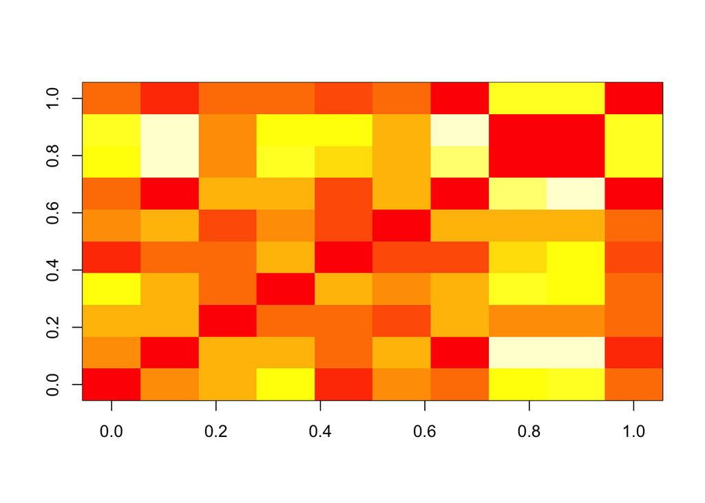

```r
d.mat <- as.matrix(dist(X.))
image(d.mat)
```

```r
out <- cmdscale(d.mat,k=n-1,eig=TRUE)
str(out)
```

```
## List of 5
##  $ points: num [1:10, 1:8] -1.411 -4.456 1.4 -0.759 -0.834 ...
##   ..- attr(*, "dimnames")=List of 2
##   .. ..$ : chr [1:10] "1" "2" "3" "4" ...
##   .. ..$ : NULL
##  $ eig   : num [1:10] 1.16e+02 3.62e+01 5.47 1.96e-14 1.25e-14 ...
##  $ x     : NULL
##  $ ac    : num 0
##  $ GOF   : num [1:2] 1 1
```